# Module 1 Part 2: Introduction to Statistics for Data Science

# Introduction

This module consists of two parts.

- **Part 1** - Setup and Installation Instructions
- **Part 2** - Introduction to Statistics for Data Science

Each part is provided in a separate notebook file. It is recommended that you follow the order of the notebooks.

# Learning Outcomes

In this module, you will learn about the following:

- Introduction to Data
- Data Types
- Variables
- Data Collection
- Sampling
- Types of Bias
- Introduction to Statistical Measures

# Reading and Resources

We invite you to further supplement this notebook with the following recommended resources:

- Diez, D., Çetinkaya-Rundel, M., & Barr, C.D. (2019). Chapter 1: Introduction to Data, Chapter 2: Summarizing data. *OpenIntro Statistics (4th Ed.)*. https://www.openintro.org/book/os/
- Rauser. J. (2014). Statistics without the agonizing pain. Keynote Strata + Hadoop 2014. https://www.youtube.com/watch?v=5Dnw46eC-0o
- Lefèvre T, Gouagna L-C, Dabiré KR, Elguero E, Fontenille D, Renaud F, et al. (2010) Beer Consumption Increases Human Attractiveness to Malaria Mosquitoes. PLoS ONE 5(3): e9546. https://doi.org/10.1371/journal.pone.0009546
- Scheurer, V. (2011). Convicted on Statistics? *Understanding Uncertainty.* University of Cambridge. Attribution-NonCommercial-ShareAlike 2.0 UK: England & Wales (CC BY-NC-SA 2.0 UK) https://understandinguncertainty.org/node/545

# A Brief History of Statistics

[figure not shown]

*Timeline of Statistics*. Please follow the link for a higher resolution image. (https://rss.onlinelibrary.wiley.com/doi/pdfdirect/10.1111/j.1740-9713.2013.00707.x)

The image above shows how the discipline of statistics has developed over time. Some of the key developments include:

[output not shown]

# Examples of Applications of Statistics

Here are a few examples of practical applications of statistics. In today's world it is difficult to find a sector, industry, government or research project that does not utilize statistics in some way.

- **Astrostatistics**: Used to process the vast amount of data produced by automated scanning of the cosmos, to characterize complex datasets, and to link astronomical data to astrophysical theory
- **Business analytics**: Applies statistical methods to datasets (including Big Data) to develop new insights and understanding of business performance and opportunities
- **Demography**: The statistical study of populations
- **Reliability Engineering**: The study of the ability of a system or component to perform its required functions under stated conditions for a specified period of time
- **Banking**: When someone deposits their money at a bank, the idea is that they will not withdraw it in the near future. So, banks lend this money to other customers to earn profit in the form of interest. They use a statistical approach for this service. They compare the number of people making deposits against the number of people requesting loans, and at the same time ascertain the estimated date the deposits will be claimed.
- **Economics**: There are so many concepts in economics that are completely dependent on statistics. For example, data collected to determine the national income, employment, and inflation are interpreted through it. In fact, the theory of demand and supply and the relationship between exports and imports are studied through statistics. A perfect example of this is the census — the census bureau uses statistics to ultimately calculate a country’s population.

# Introduction to Data

> *Scientists seek to answer questions using rigorous methods and careful observations. These observations — collected from the likes of field notes, surveys, and experiments — form the backbone of a statistical investigation and are called data.* (OpenIntro Statistics, 2019)

We will begin by introducing data and its importance in statistics.

## Working with Data

Statistics is the study of how best to collect, analyze, and draw conclusions from data. We will begin our discussion of data by presenting a generalized process for working with data:

1. **Identify the problem**: The first step in the decision making process is to identify and define the problem. A problem can be regarded as a difference between the actual situation and the desired situation which often is a hypothesis. Without a problem or a hypothesis to test, decision-making becomes a difficult and time-consuming process. In some cases, such as data mining, working without a hypothesis or problem can be appropriate.
2. **Collect relevant data**: Collecting relevant data is a very important step. Many investigations can be addressed with a small number of data collection techniques, analytic tools, and fundamental concepts of statistical inference. A clearly formulated problem asks for the subjects/cases to be studied. It is important to consider how data is collected so that it is reliable and helps achieve the end goal.
3. **Analyze the data**: This includes all the observational studies and experiments that need to be carried out to find (ideally quantify) evidence for or against the hypothesis to make better informed decisions.
4. **Form a conclusion**: With all the above mentioned steps, it is possible to gather evidence and come up with a decision. Statistics as a subject focuses on making all these steps rigorous and efficient.

## Types of Data

At the highest level, two kinds of data exist: **quantitative** and **qualitative**.

**Quantitative data** (or continuous/numerical data) deals with numbers and things you can measure **objectively** such as:

- Dimensions such as height, width, and length
- Temperature and humidity
- Prices
- Area and volume

There are 2 types of quantitative data:

1. **Discrete**: Discrete data is a count of something that cannot be made more precise. Typically, it involves integers. For instance, the number of children (or adults, or pets) in your family is discrete data, because you are counting whole, indivisible entities: you cannot have 2.5 kids, or 1.3 pets. Some examples are:
   - Measured quantities
   - Results of experiments
   - Numerical values obtained by counting
2. **Continuous**: Continuous data, on the other hand, can be divided and reduced to finer and finer levels. For example, you can measure someone's height at progressively more precise scales — meters, centimeters, millimeters, and beyond — so height is continuous data. Some examples are:
   - Values obtained by measuring (e.g. height of all students)
   - All values in a given interval of numbers (e.g. federal spending)

**Qualitative data** (sometimes referred to as categorical data) deals with characteristics and descriptors that cannot be easily measured, but can be observed **subjectively** such as:

- Personal tastes
- Textures
- Attractiveness
- Colour

When you classify or categorize something, you create qualitative or attribute data. There are several different types of qualitative data. For example, categorical data, as the name implies, is grouped into some sort of category or multiple categories. If we were to collect information about a person's pet preferences, we would have to group that information by the type of pet.

Categorical data is also data that is collected in an either/or, or yes/no fashion. For example, if you were to ask the people in an office to confirm 'Yes' or 'No' as to whether they enjoy sports, then we can display that information in a bar graph or a pie chart comparing co-workers that enjoy sports versus co-workers that do not.

Common types of qualitative data are summarized below:

- **Categorical data** which has the following subtypes:
  - **Ordinal**: When items are assigned to categories that have some kind of implicit or natural order, such as "Short, Medium, or Tall", the data is of ordinal nature. Another example is a survey question that asks us to rate an item on a 1 to 10 scale, with 10 being the best. This implies that 10 is better than 9, which is better than 8, and so on.
  - **Nominal**: Any categorical data that doesn't have an order (e.g. "blue", "red", "green"). When collecting unordered or nominal data, we assign individual items to named categories that do not have an implicit or natural value or rank. For example, if we went through a box of coloured candies and recorded them.
  - **Binary**: Binary data place things in one of two mutually exclusive categories: right/wrong, true/false, or accept/reject. It is nominal data but with only two distinct categories.
- **Other** non-numerical data such as text or video data

Broadly speaking, when you measure something and give it a number value, you create quantitative data. When you classify or judge something, you create qualitative data.

## Relationships Between Data

Many analyses are looking for a relationship between two or more variables. For example, a data scientist may like to answer some of the following questions:

1. Is federal spending, on average, higher or lower in areas with high rates of poverty?
2. If home ownership is lower than the national average in one area, will the percent of multi-unit structures in that area likely be above or below the national average?
3. Which areas have a higher average income? — those that enact one or more smoking bans or those that do not?

To answer these questions, exploratory data analysis must first be conducted. Examining summary statistics could provide insights for each of the three questions. Additionally, graphs can be used to visually summarize data and are useful for answering such questions as well. The scatter plot is a basic tool that gives the relationship between two numeric variables. More techniques will be discussed as we progress through the course. Here are a few key definitions that you will need to be familiar with as we move forward:

- **Independent variables**: If two variables are not associated, then they are said to be independent. That is, two variables are independent if there is no evident relationship between the two.
- **Associated, or dependent**: When two variables show some connection with one another, they are called associated variables. Associated variables can also be called dependent variables and vice-versa.
- **Positive association**: Two variables are said to be positively associated when they have a linear relationship with a positive slope. That means when the value of one variables increases, the value of the other variable increases as well. For example, the amount people spend is positively associated with the money people make, if we assume that people who earn more spend more.
- **Negative association**: When the value of a variable goes down when the value of another variable goes up. This is often characterized by a downward trend when the variables are plotted.

> **NOTE**: A pair of variables are either related in some way (associated) or not related (independent). *A pair of variables cannot be both associated and independent.*

Scatterplots are a great tool to compare two sets of data. When there is a strong correlation between two variables, it is possible to draw a "line of best fit" through the data points. Nonlinear patterns appear to follow along some curve. When there is no pattern, then there is no clear relationship between the variables.

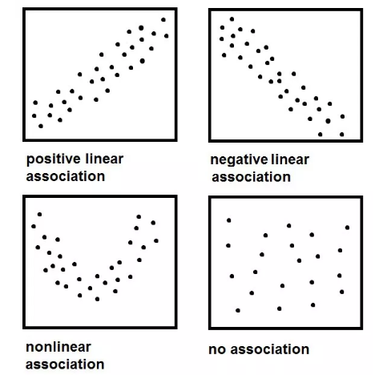

[Source: Walker, J.I. (2017)]

The above graphs shows relationships between data using scatter plots. Relationships that follow a linear pattern are linearly associated while nonlinear relationships are those that follow a pattern along a curve.

## Variables

In statistics, there are two key types of variables:

1. An **explanatory variable** is variable or a set of variables that can influence a response variable and/or explain changes in a response variable
2. A **response variable** is an observed variable

To identify the explanatory variable in a pair of variables, determine which of the two is suspected of affecting the other and plan an appropriate analysis. In some cases, there is no explanatory or response variable.

Consider a problem such as this: Is federal spending, on average, higher or lower in areas with high rates of poverty? If we suspect poverty might affect spending, then poverty is the explanatory variable and federal spending is the response variable in the relationship.

### Association does not imply causation

Labeling variables as explanatory and response **does not guarantee** the relationship between them is causal, even if there is an association (also known as a *correlation*) between the two variables. The explanatory and response labels are only used to track how we suspect the variables affect each other. There may additional hidden variables which are responsible for the association. We will explore this further in the following section.

It is also important to note that causation is an *asymmetric* relation ("X causes Y" is a different statement than "Y causes X"), whereas correlation is a *symmetric* relation ("X is correlated with Y" is an equivalent statement to "Y is correlated with X").

### Confounding Variables

In statistics, a **confounding variable** is a variable that influences both the dependent variable and independent variable giving rise to a misleading association. Confounding is a causal concept and a confounding variable is also known as a *confounding factor*, a *lurking variable,* or a *confounder*. It is also a variable which is correlated with both the explanatory and response variables.

For example, suppose some research tells us that using sunscreen actually increases skin cancer risk, so maybe there is another variable that can explain this hypothetical association between sunscreen usage and skin cancer. One important piece of information that is absent is sun exposure. If someone is out in the sun all day, they are more likely to use sunscreen and therefore are at a higher risk of developing skin cancer. Exposure to the sun is unaccounted for in the simple investigation. Hence, sun exposure is a confounding variable.

> **NOTE**: One method to justify making causal conclusions from observational studies is to exhaust the search for confounding variables, but there is no guarantee that all confounding variables can be examined or measured.

Confounding variables can arise for various reasons. Here are some common examples:

- **Confounding by indication**: When evaluating the effect of a particular drug, many times people who take the drug differ from those who do not according to the medical indication for which the drug is prescribed
- **Selection bias**: Not everyone invited to participate in a study participates, causing imbalance between groups
- **Recall bias**: Not everyone with an exposure recalls their exposure history correctly, perhaps causing uneven recall in different groups

There are many other ways confounding variables can arise including unbalanced groups by chance — especially in smaller studies.

**Collinearity** (or multicollinearity/ill-conditioning) occurs when independent variables in a regression are so highly correlated that it becomes difficult or impossible to distinguish their individual effects on the dependent variable. Thus, collinearity can be viewed as an extreme case of confounding when, for example: the same variable is essentially entered into a regression equation twice, or when two variables contain exactly the same information as two other variables.

# Data Collection

There are two primary types of data collection: observational studies and experiments.

1. **Observational Studies**:
   - Observational studies can provide evidence of a naturally occurring association between variables, but they cannot by themselves show a causal connection. For example, data may be collected via surveys, obtaining records (e.g. medical or company records), or by following a cohort of similar individuals as part of a study. In each of these situations, researchers merely observe the data as it arises. Hence, an observational study is conducted when data is collected in a way that does not directly interfere with how the data arises.
2. **Experiments**:
   - When the possibility of a causal connection needs to be investigated, an experiment can be conducted. There are both explanatory and response variables in this case. To check if there really is a causal connection between the explanatory variable and the response, a sample of individuals are identified and split into groups. The individuals in each group are assigned a treatment. In statistics, a **treatment** is a generic term which refers to the specifics of how each group is handled for the purposes of an experiment.
   - When individuals are randomly assigned to a group, the experiment is called a randomized experiment.

In general, association does not imply causation, and causation can only be inferred from a randomized experiment.

## Observational Studies

Generally, data in observational studies are collected only by monitoring what occurs, while experiments require the primary explanatory variable in a study be assigned for each subject by the researchers.

Making causal conclusions based on experiments is often reasonable. However, making the same causal conclusions based on observational data can be unreliable and is not recommended. Thus, observational studies are generally only sufficient to show associations.

### Observational Study or an Experiment?

Please watch this [12-minute keynote talk](https://www.youtube.com/watch?v=5Dnw46eC-0o) talk by John Rauser: *Statistics Without the Agonizing Pain* (Strata Hadoop 2014).

In the video, what kind of study was used to determine if beer consumption increases human attractiveness to malaria mosquitoes: observational or experimental? This is an experiment, as the researchers assigned the volunteers to a treatment group (beer or water).

For hypothesis testing, many studies focus on the comparison of groups:

- In **observational studies**, the comparison focuses on the how the response variable differs between naturally occurring groups in a sample of the population under study.
- In **experiments**, the comparison focuses on how an attribute differs across treatment groups.

### Forms of Observational Studies

Observational studies come in two forms: prospective and retrospective studies.

- **Prospective study**: A prospective study identifies individuals and collects information as events unfold. In this case, it is required to make precise estimates of either the incidence of an outcome or likelihood of the outcome.
- **Retrospective study**: Retrospective studies collect data after events have taken place. A retrospective study looks backwards and examines factors in relation to an outcome that is established at the start of the study. Special care is to be taken to avoid sources of bias and confounding in retrospective studies.

## Designing Experiments

Studies where the researchers assign treatments to cases are called experiments. When this assignment includes randomization, we refer to them as randomized experiments. Randomized experiments are fundamentally important when trying to show a causal connection between two variables. They are generally built on four principles:

1. **Controlling** differences in the group.
   - Suppose a farmer wishes to evaluate a new fertilizer. She uses the new fertilizer on one field of crops (A), while using her current fertilizer on another field of crops (B). The irrigation system on field A has recently been repaired and provides adequate water to all of the crops, while the system on field B will not be repaired until next season. She concludes that the new fertilizer is far superior.
   - The problem with this experiment is that the farmer has neglected to control for the effect of the differences in irrigation. This leads to experimental bias, the favoring of certain outcomes over others. To avoid this bias, the farmer should have tested the new fertilizer in identical conditions to the control group, which did not receive the treatment. Without controlling for outside variables, the farmer cannot conclude that it was the effect of the fertilizer, and not the irrigation system, that produced a better yield of crops
2. **Randomization** to account for variables that the researches cannot control.
   - Generally speaking, it is extremely difficult for experimenters to eliminate bias using only their expert judgment, the use of randomization in experiments is common practice. In a randomized experimental design, objects or individuals are randomly assigned (by chance) to an experimental group. Using randomization is the most reliable method of creating homogeneous treatment groups, without involving any potential biases.
3. **Replication** by collecting a sufficiently large sample.
   - Although randomization helps to ensure that treatment groups are as similar as possible, the results of a single experiment, applied to a small number of objects or subjects, should not be accepted without question. To improve the significance of an experimental result, replication, the repetition of an experiment on a large group of subjects, is required.
4. **Blocking** is used when the researchers know that other variables influence the response.
   - Experimental subjects are first divided into homogeneous blocks before they are randomly assigned to a treatment group. If, for instance, an experimenter had reason to believe that age might be a significant factor in the effect of a given medication, he might choose to first divide the experimental subjects into age groups, such as under 30 years old, 30-60 years old, and over 60 years old. Then, within each age level, individuals would be assigned to treatment groups using a completely randomized design. In a block design, both control and randomization are considered.

# Sampling

As we discussed previously, the first step towards working with data is "problem identification." Each problem refers to a target population. Say our problem is: "Does a new drug reduce the number of deaths in patients with severe heart disease?" In this study, the target population is "all patients with severe heart disease." Often times, it is too expensive to collect data for every case in a population.

Instead, a *sample* is taken. A sample represents a small subset of the total population. For instance, 100 patients with heart disease in the population might be selected, and this sample data may be used to provide an estimate of the population average.

- A **population** is a collection of people, items, or events and includes all members of a defined group that we are studying or collecting information on for data driven decisions.
- A **sample** is a small subset or fraction of a population.
- A **parameter** is any summary number, like an average or percentage, that describes the entire population. For example, the population mean $\mu$ and the population proportion $p$ are two population parameters.

We might be interested in learning about $\mu$, the average weight of all middle-aged Americans. The population consists of all middle-aged Americans, and the parameter is $\mu$. Or, we might be interested in learning about $p$, the proportion of likely American voters approving of the president's job performance. The population comprises all likely American voters, and the parameter is $p$.

The problem is that most times, we don't know the real value of a population parameter. The best we can do is estimate the parameter! This is where samples and statistics come in to play.

## Sampling Principles

A sample is a finite subset selected from the population with the objective of investigating its properties. The number of units in the sample is known as the **sample size**. A sample helps us draw conclusions about the full population. There are 2 key properties of a properly selected sample:

1. The sample is **randomly** selected.
   - In general, we always seek to randomly select a sample from a population. The most basic type of random selection is equivalent to how raffles are conducted. A random sample is a group or set chosen from a larger population in a random manner that allows for each member of the larger group to have an equal chance of being chosen.
   - What if we picked a sample by hand? It is entirely possible that the sample could be skewed to that person's interests, which may be entirely unintentional. This introduces bias into a sample. Random sampling helps resolve this problem. The most basic random sample is called a simple random sample.
2. The sample is a **representative** sample.
   - A representative sample is a group or set chosen from a larger statistical population that adequately replicates the larger group according to whatever characteristic or quality is under study.

However, although random sampling helps minimize bias, there are still ways in which bias can arise. For example:

- In cases of surveys where the non-response rate is high — even if people are picked at random — caution must be taken. For instance, if only 30% of the people randomly sampled for a survey actually respond, then it is unclear whether the results are representative of the entire population. This *non-response bias* can skew results.
- In *convenience samples*, only individuals easily accessible are included in the sample. For instance, if a political survey is performed by stopping people walking on Bay Street, this will not represent all of the city of Toronto. It is often difficult to discern what sub-population a convenience sample actually represents.

## Sampling Methods

We will now introduce some common sampling methods.

**Simple random sampling**: Each member of the population has an equal chance of being included in the final sample.

For example, at a fundraising event, every attendee's name is entered for the chance to win a prize. Names are selected at random, then returned to the jar, giving individuals multiple opportunities to win prizes.

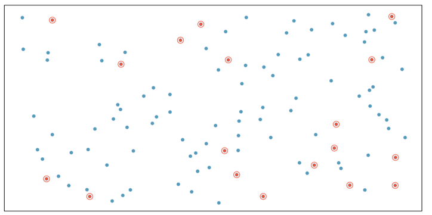

**Stratified sampling**: Random sampling from groups of similar cases.

Stratified sampling is possible when the population can be partitioned into groups based on a factor that may influence the variable that is being measured. These groups are called strata. An individual group is called a stratum. The process for stratified sampling is a follows:

1. Partition the population into groups (strata)
2. Select a simple random sample from each group
3. Collect data on the sampling units selected from each group

For example, if we were to pick a stratified sample of people living in Canada, we could choose the strata to be the 6 time-zones (Newfoundland, Atlantic, Eastern, Central, Mountain, Pacific). We can then draw a random sample of 500 people from each of the time zones, resulting in a total of 3000 people included in our stratified sample.

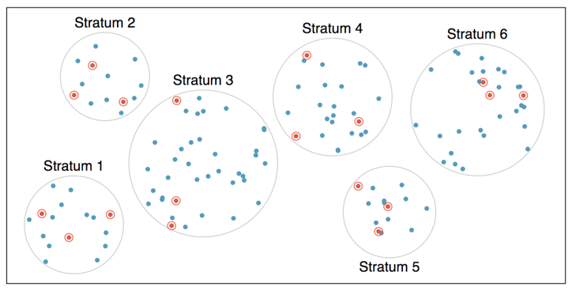

When there is a lot of case-to-case variability within a group, but the groups are very similar:

- **Cluster sampling**: Break up the population into groups (clusters or strata), sample a fixed number of clusters and include all observations from each of those clusters in a sample
  - It is important to note that, unlike with the strata in stratified sampling, the clusters should be microcosms, rather than subsections, of the population. Each cluster should be heterogeneous. Additionally, the statistical analysis used with cluster sampling is not only different, but also more complicated than that used with stratified sampling. Cluster sampling really works best when there are a reasonable number of clusters relative to the entire population.
- **Multistage sampling**: Similar to cluster sampling, but instead of including all observations from each selected cluster, collect random samples within each selected cluster

Please note that although useful in certain circumstances, the use of stratified or cluster sampling can still be very subjective and can introduce bias into the sample.

## Biases

Randomized experiments are the gold standard for data collection, but they do not ensure an unbiased perspective in all cases. Neglecting to control differences in groups can cause bias (as in our example of the farmer evaluating fertilizer above). **Bias** is the intentional or unintentional favouring of one group or outcome over other potential groups or outcomes in the population.

Two main categories of biases:

1. **Selection Bias**: The bias that results from an unrepresentative sample is called selection bias
   - *Undercoverage*: Occurs when some members of the population are inadequately represented in the sample
   - *Non-response bias*: Bias that results when respondents differ in meaningful ways from non-respondents
   - *Voluntary bias*: Sample members are self-selected volunteers
2. **Response Bias**: Response bias refers to the bias that results from problems in the measurement process
   - *Leading questions*: Questions that encourage the expected answer
   - *Social desirability*: Responses may be biased toward what the respondents believe is socially desirable

Statistical studies often employ several tools to help minimize bias such as the use of treatment groups, control groups, and placebos. An experiment is a study that imposes a treatment (or control) to the subjects (participants), controls their environment (for example, restricting their diets, giving them certain dosage levels of a drug or placebo), and records the responses.

The purpose of most experiments is to pinpoint a cause-and-effect relationship between two factors (such as alcohol consumption and impaired vision, or dosage level of a drug and intensity of side effects).

### Treatment and Control Group Tests

Most experiments try to determine whether some type of experimental treatment (or important factor) has a significant effect on an outcome. For example, does zinc help to reduce the length of a cold? Subjects who are chosen to participate in the experiment are typically divided into two groups: a treatment group and a control group.

1. The **treatment group** consists of participants who receive the experimental treatment whose effect is being studied (in this case, zinc tablets).
2. The **control group** consists of participants who do not receive the experimental treatment being studied. Instead, they get a placebo (a fake treatment — e.g. a sugar pill); a standard, nonexperimental treatment (such as vitamin C, in the zinc study); or no treatment at all, depending on the situation.

After the experiment has been performed, the responses of those in the treatment group are compared with the responses from the control group to look for differences that are statistically significant (i.e. unlikely to have occurred just by chance).

The study is ideally *double-blind* — researchers who interact with the participants and the participants themselves are all unaware of which group they belong to.

### Placebo Tests

A placebo is a fake treatment, such as a sugar pill used in a medical trial. Placebos are given to the control group to account for a psychological phenomenon called the placebo effect, in which patients receiving a fake treatment still report having a response, as if it were the real treatment. For example, after taking a sugar pill a patient experiencing the placebo effect might say, “Yes, I feel better already.” By measuring the placebo effect in the control group, you can assess what portion of the reports from the treatment group were due to a real physical effect and what portion were likely due to the placebo effect.

### Cognitive Bias

[figure not shown]

(Source: https://commons.wikimedia.org/wiki/File:The_Cognitive_Bias_Codex_-_180%2B_biases,_designed_by_John_Manoogian_III_(jm3).png)

The diagram above shows the four problems that biases help us address, namely: information overload, lack of meaning, the need to act fast, and how to know what needs to be remembered for later.

Please follow the link above for a higher resolution version of the image.

### Other Types of Biases

There are many types of bias that exist. Here are some resources for you to explore:

- List of cognitive biases used in the previous image: https://en.wikipedia.org/wiki/List_of_cognitive_biases
- List of types of statistical biases: https://en.wikipedia.org/wiki/Bias_(statistics)

# Introduction to Statistical Measures

## Mean and Median

Statistical measures and metrics are used to study numerical data. We will begin by introducing two of the most common statistical metrics — the **mean** and **median**.

[output not shown]

**Example**: Consider the following list of numbers.

$$ { 9, 41, 19, 27, 14, 2} $$

First, we'll calculate the mean:

$$\overline{X} = \frac{(9+41+19+27+14+2)}{6} = 18.67 $$

Next, we'll calculate the median. We'll begin by sorting the list of numbers:

$$ {2, 9, 14, 19, 27, 41 } $$

Now that the list has been sorted, we'll identify the middle number of the list. As there are an even number of values we select the 2 middle numbers:

$$ 14, 19 $$

**NOTE**: In this example, we have rounded the mean to 2 decimals places.

The mean and median are two statistics we can use to quantify observations. Other measures include: minimum, maximum, distribution of data, variability, quartiles, and outliers.

**Outliers** are values that are unusual compared to the rest of the dataset (i.e. especially small or large in numerical value). If we were to find the average salary of 5 employees, whose salaries are \$40k, \\$50k, \$45k, \\$40k and \$100k, we compute mean to be sum of salaries divided by 5 which is \\$55k. However, this isn't the best representation of the group because most of the salaries are between \$40k and \\$50k. The mean is skewed by the one large salary (\$100k). In this situation we would typically use a better measure of central tendency, such as the median.

## Variance and Standard Deviation

Computing the mean or median of a dataset is often not enough. Variability in the data is also important. Here, we introduce two measures of variability: the **variance** and the **standard deviation**. The standard deviation roughly describes how far away the typical observation is from the mean. We call the distance of an observation from the mean its deviation.

Since these measures are based on mean, they are susceptible to skew.

[output not shown]

**Example**: Consider the following list of numbers — these are the same numbers we saw in the previous section.

$$ { 9, 41, 19, 27, 14, 2} $$

First, we'll compute the mean:

$$\overline{X} = \dfrac{\displaystyle\sum_{i=1}^{n} x_i}{n}$$$$\overline{X} = \frac{(9+41+19+27+14+2)}{6} = 18.67 $$

Next, we'll compute the variance:

$$\sigma ^{2} = \dfrac{\displaystyle\sum_{i=1}^{n} (x_i - \overline{X})^2}{n - 1}$$$$\sigma ^{2} = \frac{(9-18.67)^2 + (41-18.67)^2 + (19-18.67)^2 + (27-18.67)^2 + (14-18.67)^2 + (2-18.67)^2}{6 - 1} = 192.27$$

Finally, we'll compute the standard deviation:

$$\sigma = \sqrt{\sigma ^{2}} = \sqrt{192.27} = 13.87$$

**NOTE**: In this example, we have rounded the variance and standard deviation to 2 decimals places.

**End of Module**

You have reached the end of this module.

If you have any questions, please reach out to your peers using the discussion boards. If you and your peers are unable to come to a suitable conclusion, do not hesitate to reach out to your instructor on the designated discussion board.

When you are comfortable with the content, you may proceed to the next module.

# References

- Diez, D., Çetinkaya-Rundel, M., & Barr, C.D. (2019). *OpenIntro Statistics (4th Ed.)*. https://www.openintro.org/book/os/
- Bias, statistics, n.d. Retrieved on Dec 5, 2018 from Wikipedia https://en.wikipedia.org/wiki/Bias_(statistics)
- Champkin, J. (2014). *The timeline of statistics*. Significance. Retrieved December 5, 2018 from https://www.statslife.org.uk/history-of-stats-science/1190-the-timeline-of-statistics
- Cognitive Bias Codex, 2016. Retrieved Dec 5, 2018 from Wikimedia Commons https://commons.wikimedia.org/wiki/File:The_Cognitive_Bias_Codex_-_180%2B_biases,_designed_by_John_Manoogian_III_(jm3).png Attribution-ShareAlike 4.0 International (CC BY-SA 4.0)
- Data, (n.d.). Retrieved Dec 5, 2018 from Business Dictionary http://www.businessdictionary.com/
- Data, (n.d.). Retrieved Dec 5, 2018 from Cambridge Dictionary https://dictionary.cambridge.org/dictionary/english/data
- List of cognitive biases, n.d. Retrieved on Dec 5, 2018 from Wikipedia https://en.wikipedia.org/wiki/List_of_cognitive_biases
- Rauser, J. (2014). Statistics Without the Agonizing Pain. Strata Hadoop 2014. Retrieved from https://www.youtube.com/watch?v=5Dnw46eC-0o
- United States Census, 2018. Economic and Demographic information by County. Retrieved Dec 5, 2018 from https://www.census.gov/data.html
- Walker, J.I. (2017). *Reading Scatterplots*. Retrieved Dec 5, 2018 from https://www.mathbootcamps.com/reading-scatterplots/